# Chapter 1

David Kane

8/6/2020

Today’s class will be based on the first chapter of the textbook, which covers how to make basic and advanced plots using the **tidyverse** package. We will be using the “kenya” data set from the **PPBDS.data** package. To learn more about this package, read the description [here](https://davidkane9.github.io/PPBDS.data/). Try `?kenya`. Data is from “Electoral Administration in Fledgling Democracies: Experimental Evidence from Kenya” ([pdf](https://papers.ssrn.com/sol3/papers.cfm?abstract_id=3520421)).

### Scene 1

**Prompt:** Let’s first explore the data by creating a basic histogram using `mean_age`. Use the `bins` argument to set an appropriate number of bins in your histogram, and set your range of values to ignore outliers. As always, label your plot appropriately with axis labels and a title. What does your plot tell you about the general age of Kenya’s voting population? Along the way, you and your posse should do the usual data exploration: `glimpse()`, `summary()`, `sample_n()`, `view()` and so on. `xlim()` may be a useful function.

**Answer:**

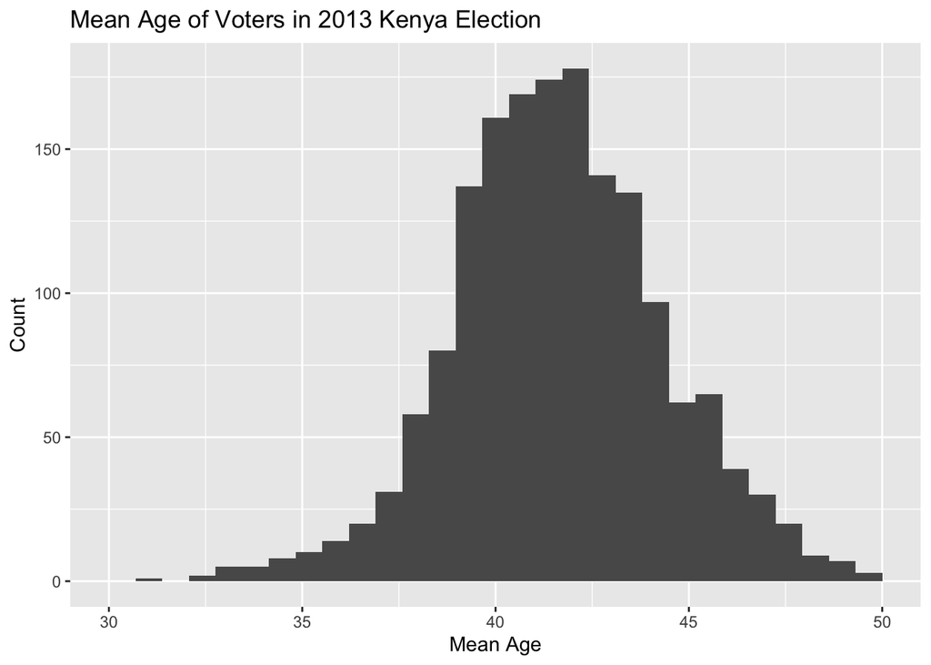

```r
# The warning message is caused by xlim() cutting off three of the observations.
# I could not find a way to make that warning go away. Maybe it would be cleaner
# to drop the outlier data before doing the plot?

x %>%
  ggplot(mapping = aes(x = mean_age)) +
    geom_histogram(bins = 30) +
    xlim(c(30, 50)) +
    labs(x = "Mean Age",
         y = "Count",
         title = "Mean Age of Voters in 2013 Kenya Election")
```

**Comments:** Students will learn about `xlim()` and `bins`. Have students explore changing the number of bins to see how that affects the histogram.

### Scene 2

**Prompt:** Next, let’s explore the `reg_inc` variable in more detail by creating another histogram. Again, be sure to use an appropriate number of bins using the `bins` argument. You will need to re-scale the x-axis. Explore the difference between using a log scale versus a square root scale. Which one is better for this particular dataset, and why? `reg_inc` is the increase in voter registration in a community. Do you believe those outlier values? Why or why not?

**Answer:**

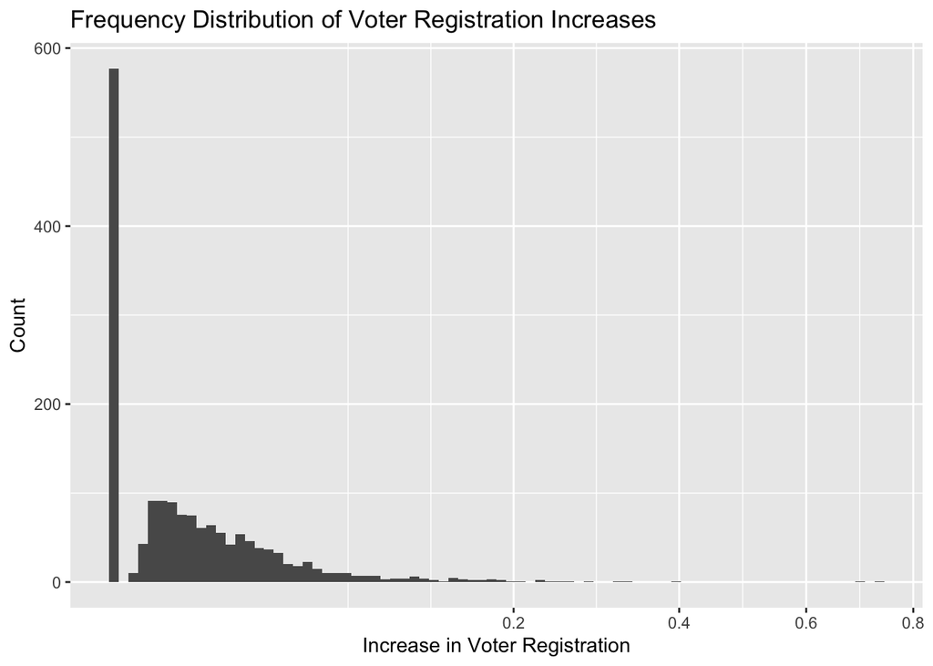

```r
x %>%
  ggplot(aes(reg_inc)) +
  geom_histogram(bins = 80) +
  scale_x_sqrt() +
  labs(x = "Increase in Voter Registration",
       y = "Count",
       title = "Frequency Distribution of Voter Registration Increases")
```

**Comments:** Students should set a higher number of bins since there are a lot of data points. Students should notice that using a square root scale is better for this dataset because it takes into account the `reg_inc == 0` data points, which make up a large portion of the dataset, while using a log scale gets rid of those points and does not accurately reflect the data.

### Scene 3

**Prompt:** We have seen that most polling locations experienced no increase in voter registration. To get a better understanding of the experiment, use a bar plot to visualize how many times each treatment was used. To make things more interesting, load the `ggthemes` library and choose a theme from the following web page to use for your plot: https://mran.microsoft.com/snapshot/2017-02-04/web/packages/ggthemes/vignettes/ggthemes.html

**Answer:**

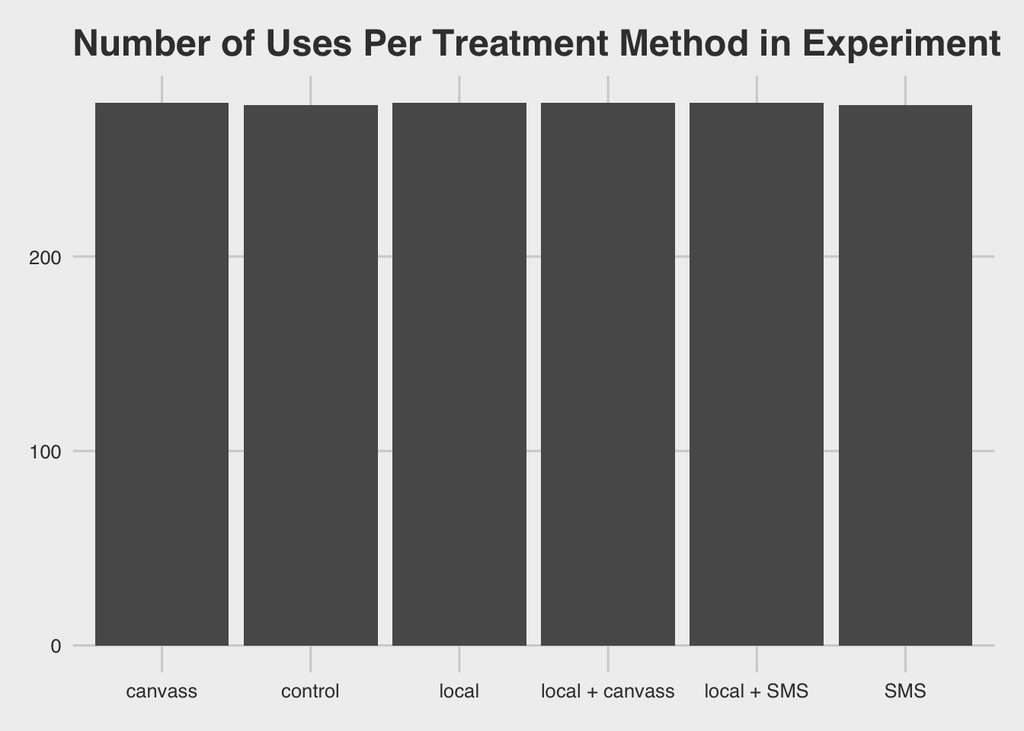

```r
library(ggthemes)
kenya %>%
  ggplot(mapping = aes(x = treatment)) +
  geom_bar() +
  labs(x = "Treatment Method",
       y = "Number of Uses",
       title = "Number of Uses Per Treatment Method in Experiment") +
  theme_fivethirtyeight()
```

**Comments:** The purpose of this question is to verify the randomization of the experiment. While the plot is not that interesting, students should see that each treatment was generally tested an equal number of times.

For background info on what the treatment methods indicate:

- “Local” sent staff members with mobile registration equipment to register citizens
- “Canvass” had civic educators provide citizens living near polling locations information about registration and how to vote
- “SMS” sent mobile phone messages to existing registered voters telling them to remind their unregistered friends to register

### Scene 4

**Prompt:** Now let’s look at how many times each treatment was used per county. Do this by creating another bar graph. You will need to use geom_bar’s `position` argument and ggplot’s `fill` argument.

**Answer:**

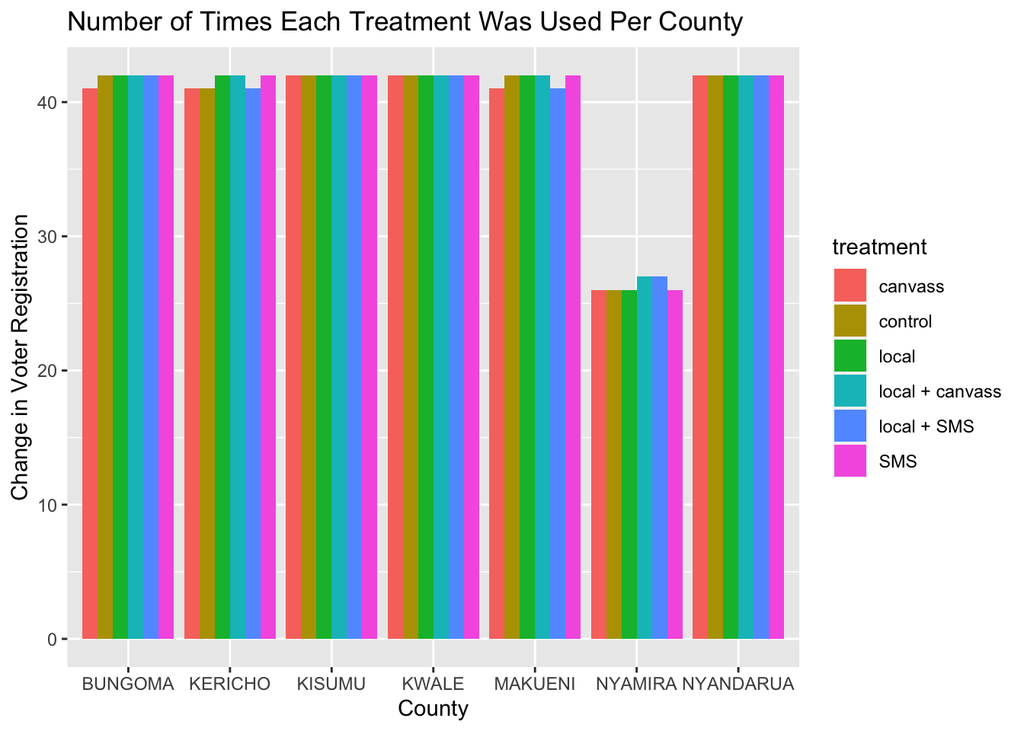

```r
x %>%
  ggplot(mapping = aes(x = county, fill = treatment)) +
  geom_bar(position = "dodge") +
  labs(x = "County", y = "Change in Voter Registration",
       title = "Number of Times Each Treatment Was Used Per County")
```

**Comments:** This is similar to the previous question, except now, students will see that treatments were generally used equally across counties, except Nyamira, which had a smaller number of data points. Suggest to students to try `table(kenya$treatment)` and `table(kenya$county)` in the console to verify their results.

### Scene 5

**Prompt:** Now, let’s look at the effectiveness of the `local + SMS` treatment method using a box plot.

**Answer:**

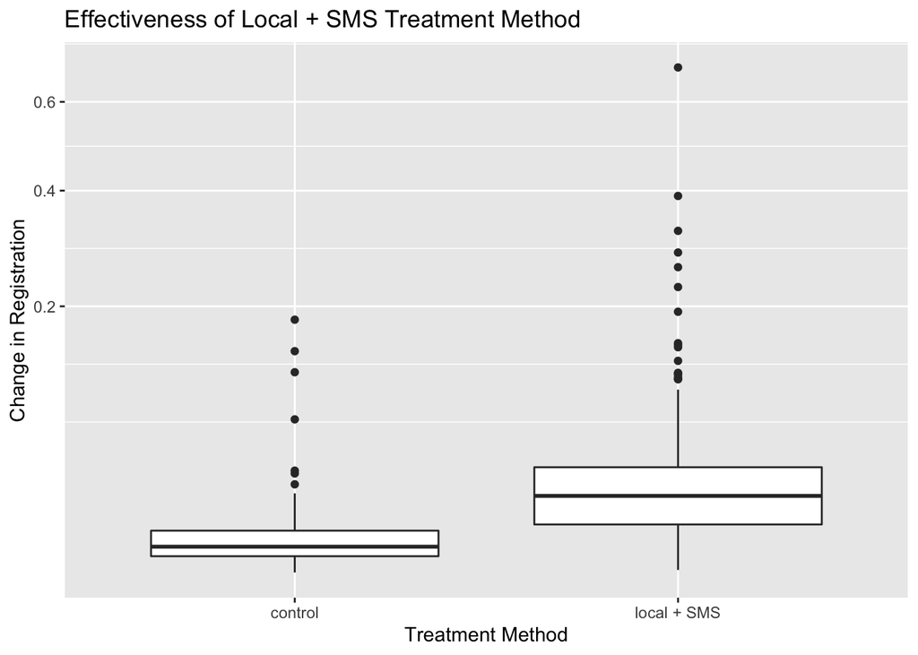

```r
library(ggthemes)
x %>%
  filter(treatment %in% c("control", "local + SMS")) %>%
  filter(! reg_inc == 0) %>%
  ggplot(mapping = aes(x = treatment, y = reg_inc)) +
  geom_boxplot() +
  scale_y_sqrt() +
  labs(x = "Treatment Method", y = "Change in Registration",
       title = "Effectiveness of Local + SMS Treatment Method")
```

**Comments:** To measure the effectiveness of a particular treatment, students should compare it with `control`. Suggest to students to experiment with filtering out values where `reg_inc == 0` versus keeping them in, and ask them which is better. Since filtering out `reg_inc == 0`, mostly affects the `control` variable, it is better to filter them out (since it’s assumed that doing nothing should theoretically not cause an increase in voters).

### Scene 6

**Prompt:** We have seen that at least one treatment method was clearly effective in increasing voter registration. Now we want to compare the changes in voter registration across all treatments. Calculate the mean increase in registration for each treatment, and plot your results onto a bar graph.

**Answer:**

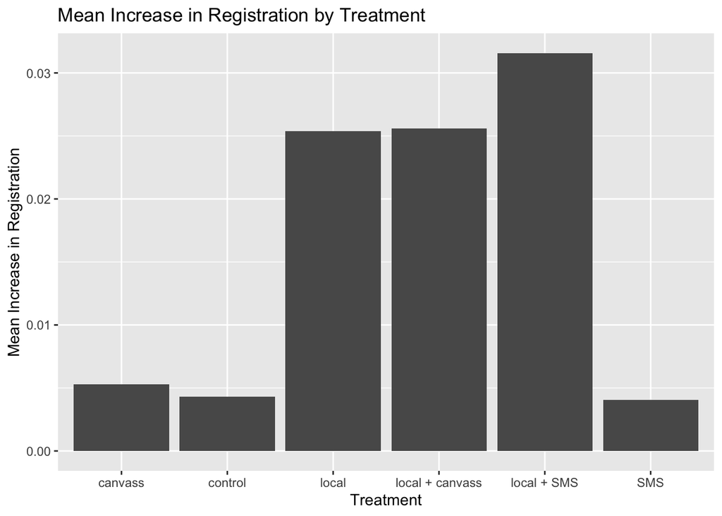

```r
x %>%
  group_by(treatment) %>%
  summarise(mean_increase = mean(reg_inc)) %>%
  ggplot(mapping = aes(x = treatment, y = mean_increase)) +
  geom_col() +
  labs(x = "Treatment",
       y = "Mean Increase in Registration",
       title = "Mean Increase in Registration by Treatment")
```

**Comments:** The goal of this question is to have students practice using `group_by` and `summarize`.

### Scene 7

**Prompt:** Now we know which treatment methods were most effective by looking at the mean increases. However, the previous graph doesn’t tell us much about the distribution of `reg_inc` values across treatments. Create a violin plot that shows the density of registration increases by treatment, and layer a box plot on top. Remember to use an appropriate scaling method for your x-axis.

**Answer:**

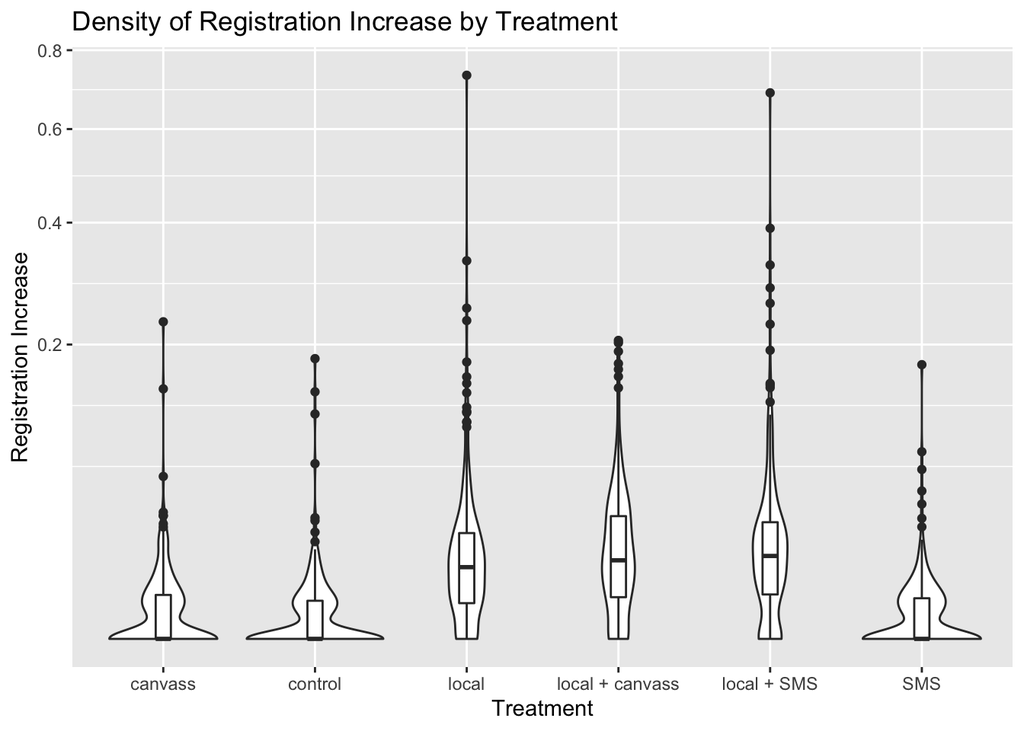

```r
x %>%
  ggplot(mapping = aes(x = treatment, y = reg_inc)) +
  geom_violin() +
  scale_y_sqrt() +
  labs(x = "Treatment",
       y = "Registration Increase",
       title = "Density of Registration Increase by Treatment") +
  geom_boxplot(width = 0.1)
```

**Comments:** Students should see that they must use a square root scaling here again, since a log scaling does not properly depict the frequency of `reg_inc == 0`. Students will need to adjust the width of the layering box plot to make things look nice.

### Scene 8

**Prompt:** We saw in the previous graph that there is a high density of values where `reg_inc == 0`. We can explore this in more detail by creating a plot of the number of polling locations where `reg_inc == 0`. Replicate the following plot.

Hint: Look into theme()

**Answer:**

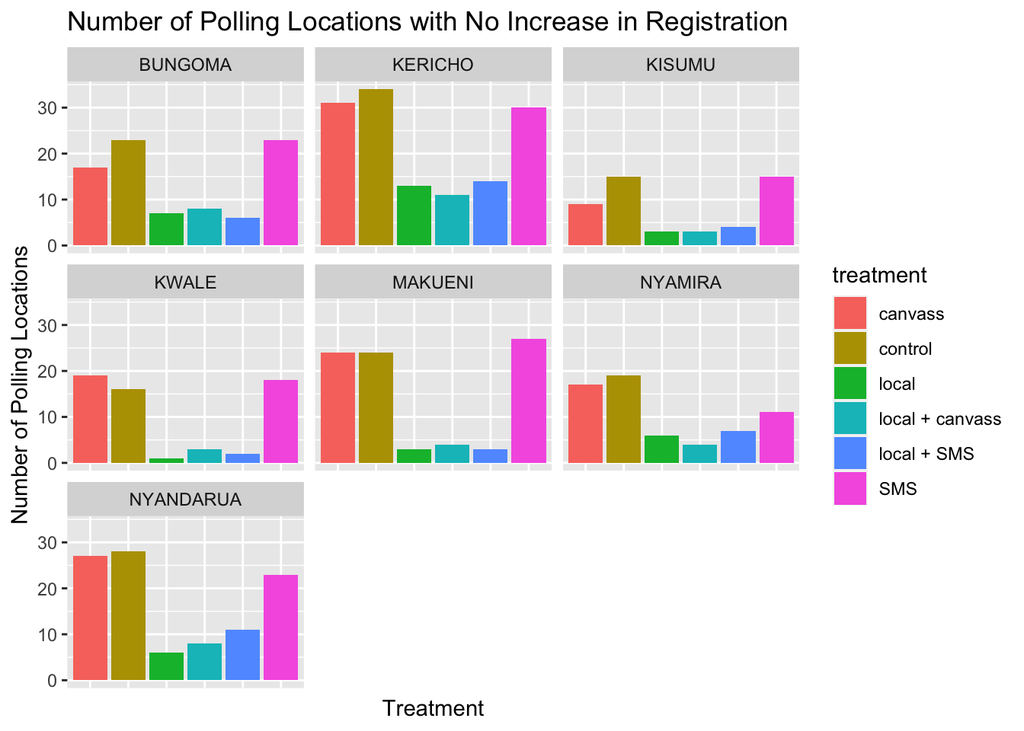

```r
x %>%
  filter(reg_inc == 0) %>%
  group_by(treatment, county) %>%
  summarize(count = n()) %>%
  ggplot(mapping = aes(x = treatment, y = count, fill = treatment)) +
  geom_col() +
  theme(axis.ticks.x = element_blank(),
        axis.text.x = element_blank()) +
  labs(x = "Treatment",
       y = "Number of Polling Locations",
       title = "Number of Polling Locations with No Increase in Registration") +
  facet_wrap(~ county)
```

**Comments:** Students here will need to figure out the correct tidyverse pipeline that counts the number of data points where `reg_inc == 0`. Another key point is that the default labels on the x-axis will be too crowded, so students should use theme() to remove axis labels and tick marks while instead using `fill = treatment`.

### Scene 9

**Prompt:** Create a scatterplot to explore the relationship between `poverty` and `reg_inc`, using the `alpha` argument to more clearly show overlapping points. Label your axes nicely and include a title. Add a linear line of best fit - this will require use of the `method` argument in `geom_smooth()`. What relationship do you see?

Hint: You will need to use a log scale on both axes to see a clear connection between the two variables.

**Answer:**

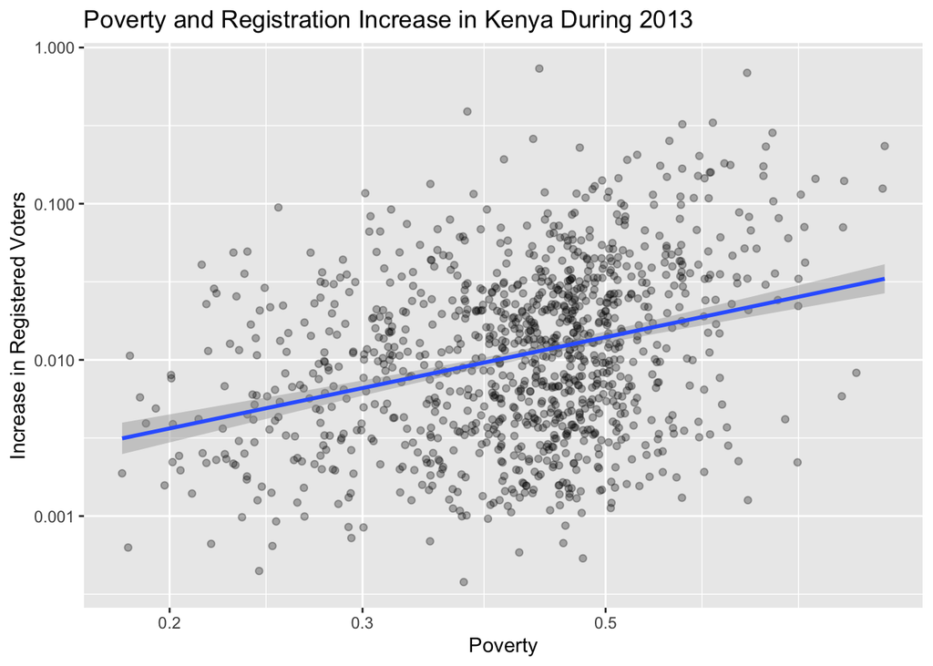

```r
x %>%
  filter(! reg_inc == 0) %>%
  ggplot(mapping = aes(x = poverty, y = reg_inc)) +
  geom_point(alpha = 0.3) +
  scale_x_log10() +
  scale_y_log10() +
  geom_smooth(method = "lm") +
  labs(x = "Poverty", y = "Increase in Registered Voters",
       title = "Poverty and Registration Increase in Kenya During 2013")
```

**Comments:** Students should see here that it’s better to filter out values where `reg_inc == 0` because this does not change the correlation between the two variables. Students should understand what the `method` and `alpha` arguments do.

### Scene 10

**Prompt:** We see that there is a positive correlation between `poverty` and `reg_inc` based on the previous scene. Another interesting question to ask is whether the effectiveness of each treatment method is impacted by poverty level. Create a plot that explores this relationship.

**Answer:**

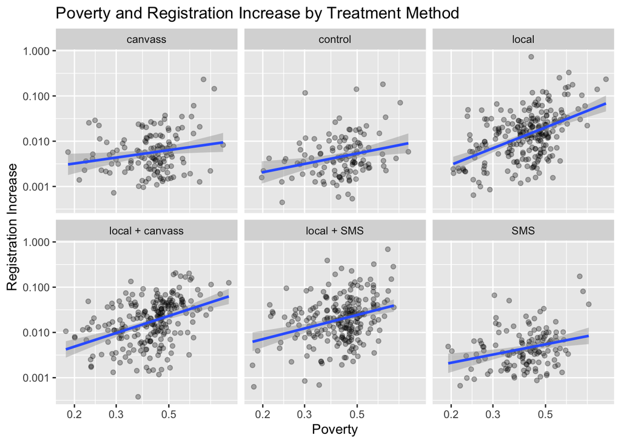

```r
x %>%
  filter(! reg_inc == 0) %>%
  ggplot(mapping = aes(x = poverty, y = reg_inc)) +
  geom_point(alpha = 0.3) +
  scale_x_log10() +
  scale_y_log10() +
  geom_smooth(method = "lm") +
  facet_wrap(~ treatment) +
  labs(x = "Poverty",
       y = "Registration Increase",
       title = "Poverty and Registration Increase by Treatment Method")
```

**Comments:** Students should see that treatment methods involving `local` have a higher positive correlation between poverty and registration increase.